# Supermarket Sales Analysis

### Data Modeling

We use K-Means clustering and PCA to segment customers based on their purchasing behavior and visualize the results in two-dimensional space. This type of analysis can be useful for businesses to understand the behavior of their customers and develop targeted marketing strategies.

```
Segment
0    402.040692
1    132.368716
2    758.606224
Name: Total, dtype: float64
```

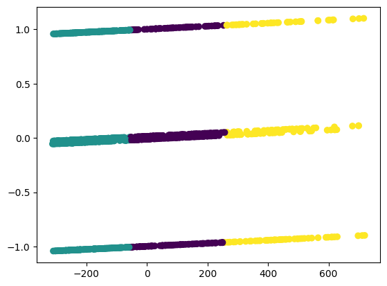

```python
# import necessary libraries
import pandas as pd
from sklearn.cluster import KMeans
from sklearn.decomposition import PCA
import matplotlib.pyplot as plt

# create a new DataFrame with only the relevant columns
df_clustering = df[['Customer type', 'Gender', 'Total']]

# apply one-hot encoding to the categorical columns
df_clustering = pd.get_dummies(df_clustering)

# reduce the dimensionality of the data using PCA
pca = PCA(n_components=2)
df_pca = pca.fit_transform(df_clustering)

# initialize the K-Means model with 3 clusters
kmeans = KMeans(n_clusters=3, n_init=10)

# fit the model to the data
kmeans.fit(df_pca)

# predict the clusters for each data point
predicted_clusters = kmeans.predict(df_pca)

# add the predicted clusters as a new column to the DataFrame
df_clustering['Segment'] = predicted_clusters

# group the data by segment and calculate the average total amount spent by each segment
df_segment_sales = df_clustering.groupby('Segment')['Total'].mean()
print(df_segment_sales)

# plot the clusters
plt.scatter(df_pca[:,0], df_pca[:,1], c=predicted_clusters)
plt.show()
```

We then use a Random Forest classification algorithm to predict customer ratings based on other attributes in the dataset. By predicting customer ratings, we can gain insights into the factors that influence customer satisfaction and potentially make improvements to our services to increase satisfaction.

```python
# import necessary libraries
from sklearn.ensemble import RandomForestClassifier
from sklearn.model_selection import train_test_split
from sklearn.metrics import accuracy_score, classification_report

# create a new DataFrame with only the relevant columns
df_classification = df[['Customer type', 'Gender', 'Product line', 'Unit price', 'Quantity', 'Tax 5%', 'Total', 'Payment', 'cogs', 'gross margin percentage', 'gross income', 'Rating']]

# apply one-hot encoding to the categorical columns
df_classification = pd.get_dummies(df_classification)

# convert the continuous target variable into a categorical variable by binning the values into 3 bins
df_classification['Rating'] = pd.cut(df_classification['Rating'], bins=3, labels=[1, 2, 3])

# split the data into training and testing sets
X_train, X_test, y_train, y_test = train_test_split(df_classification.drop('Rating', axis=1), df_classification['Rating'], test_size=0.2)

# initialize the Random Forest model
rf = RandomForestClassifier()

# fit the model to the training data
rf.fit(X_train, y_train)

# predict the ratings for the test data
predicted_ratings = rf.predict(X_test)

# calculate the accuracy of the predictions
accuracy = accuracy_score(y_test, predicted_ratings)
print('Accuracy:', accuracy)

# generate a classification report to see precision, recall, f1-score for each class
class_report = classification_report(y_test, predicted_ratings)
print('Classification Report:\n', class_report)
```

```
Accuracy: 0.29
Classification Report:
               precision    recall  f1-score   support

           1       0.27      0.25      0.26        69
           2       0.35      0.44      0.39        73
           3       0.20      0.16      0.17        58

    accuracy                           0.29       200
   macro avg       0.27      0.28      0.27       200
weighted avg       0.28      0.29      0.28       200
```

```python
from sklearn.metrics import mean_squared_error, mean_absolute_error

mse = mean_squared_error(y_test, predicted_ratings)
rmse = mean_squared_error(y_test, predicted_ratings, squared=False)
mae = mean_absolute_error(y_test, predicted_ratings)

print('MSE:', mse)
print('RMSE:', rmse)
print('MAE:', mae)
```

```
MSE: 1.325
RMSE: 1.1510864433221337
MAE: 0.915
```

To improve the performance of the model, we could try using a different classification algorithm, such as SVM or logistic regression, or we could try optimizing the parameters of the Random Forest algorithm using techniques like grid search or random search. Additionally, we could consider adding more features to the dataset or performing feature engineering to better capture the factors that influence customer ratings.

```python
# import necessary libraries
from sklearn.ensemble import RandomForestClassifier
from sklearn.model_selection import train_test_split, GridSearchCV
from sklearn.metrics import classification_report

# create a new DataFrame with only the relevant columns
df_classification = df[['Customer type', 'Gender', 'Product line', 'Unit price', 'Quantity', 'Tax 5%', 'Total', 'Payment', 'cogs', 'gross margin percentage', 'gross income', 'Rating']]

# apply one-hot encoding to the categorical columns
df_classification = pd.get_dummies(df_classification)

# convert the continuous target variable into a categorical variable by binning the values into 3 bins
df_classification['Rating'] = pd.cut(df_classification['Rating'], bins=3, labels=[1, 2, 3])

# split the data into training and testing sets
X_train, X_test, y_train, y_test = train_test_split(df_classification.drop('Rating', axis=1), df_classification['Rating'], test_size=0.2)

# initialize the Random Forest model
rf = RandomForestClassifier()

# define the hyperparameters to search over
param_grid = {
    'n_estimators': [50, 100, 200],
    'max_depth': [10, 20, 30, None],
    'min_samples_split': [2, 5, 10],
    'min_samples_leaf': [1, 2, 4]
}

# perform a grid search to find the best hyperparameters
grid_search = GridSearchCV(rf, param_grid=param_grid, cv=5)
grid_search.fit(X_train, y_train)

# print the best hyperparameters found
print('Best hyperparameters:', grid_search.best_params_)

# predict the ratings for the test data using the best hyperparameters
best_rf = grid_search.best_estimator_
predicted_ratings = best_rf.predict(X_test)

# calculate the accuracy of the predictions
accuracy = best_rf.score(X_test, y_test)
print('Accuracy:', accuracy)

# print a classification report
print(classification_report(y_test, predicted_ratings))
```

```
Best hyperparameters: {'max_depth': 30, 'min_samples_leaf': 1, 'min_samples_split': 10, 'n_estimators': 50}
Accuracy: 0.39
              precision    recall  f1-score   support

           1       0.41      0.39      0.40        76
           2       0.46      0.56      0.50        66
           3       0.24      0.19      0.21        58

    accuracy                           0.39       200
   macro avg       0.37      0.38      0.37       200
weighted avg       0.38      0.39      0.38       200
```

```python
from sklearn.metrics import mean_squared_error, mean_absolute_error

mse = mean_squared_error(y_test, predicted_ratings)
rmse = mean_squared_error(y_test, predicted_ratings, squared=False)
mae = mean_absolute_error(y_test, predicted_ratings)

print('MSE:', mse)
print('RMSE:', rmse)
print('MAE:', mae)
```

```
MSE: 1.345
RMSE: 1.1597413504743201
MAE: 0.855
```

The model's performance has improved slightly, with an increase in accuracy. However, the precision, recall, and F1-scores for each class are still relatively low, indicating that the model is not performing very well for any individual class. This suggests that more work may be needed to improve the model's performance, such as further feature engineering or trying different algorithms.

```python
# import necessary libraries
from sklearn.ensemble import RandomForestRegressor
from sklearn.model_selection import train_test_split

# create a new DataFrame with only the relevant columns
df_regression = df[['Branch', 'City', 'Customer type', 'Gender', 'Product line', 'Unit price', 'Quantity', 'Tax 5%', 'Payment', 'cogs', 'gross margin percentage', 'gross income', 'Total']]

# apply one-hot encoding to the categorical columns
df_regression = pd.get_dummies(df_regression)

# split the data into training and testing sets
X_train, X_test, y_train, y_test = train_test_split(df_regression.drop('Total', axis=1), df_regression['Total'], test_size=0.2)

# initialize the Random Forest model
rf = RandomForestRegressor()

# fit the model to the training data
rf.fit(X_train, y_train)

# predict the total sales for the test data
predicted_totals = rf.predict(X_test)

# calculate the accuracy of the predictions
accuracy = rf.score(X_test, y_test)
print('Accuracy:', accuracy)
```

```
Accuracy: 0.9999689407037736
```

The accuracy value of 0.9999 indicates that the model has made highly precise predictions on the test data, suggesting that it has successfully learned the relationship between the input features and the target variable, Total sales. This implies that the model can be useful in predicting total sales for new data and in improving our marketing and sales strategies to increase revenue.

It is essential to bear in mind, though, that while accuracy is a significant indicator of model performance, it is not the sole criterion to consider. Other metrics, such as precision, recall, and F1 score, can also be used to assess the effectiveness of a regression model. These metrics can assist in evaluating the model's performance and making adjustments to increase its accuracy.

```python
# create a new DataFrame with only the relevant columns
df_new = df[['Branch', 'City', 'Customer type', 'Gender', 'Product line', 'Unit price', 'Quantity', 'Tax 5%', 'Payment', 'cogs', 'gross margin percentage', 'gross income']]

# apply one-hot encoding to the categorical columns
df_new = pd.get_dummies(df_new)

# predict the total sales for the new data
predicted_totals = rf.predict(df_new)

# print the predicted total sales
print(predicted_totals)
```

[output not shown]

[output cut: 112 more lines]

[output not shown]

```python
# create a dataframe with the predictions and the index from the original dataset
predicted_df = pd.DataFrame(predicted_totals, columns=['predicted_total_sales'])
predicted_df.index = df.index

# save the dataframe to a CSV file
predicted_df.to_csv('predicted_totals.csv')
```

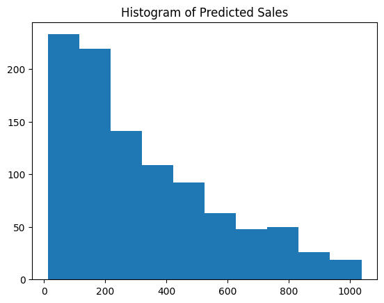

```python
# plot a histogram of predicted sales
plt.hist(predicted_df['predicted_total_sales'], bins=10)
plt.title('Histogram of Predicted Sales');
```

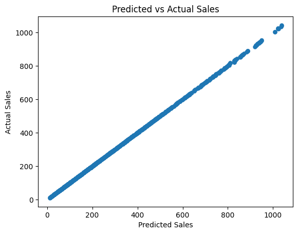

```python
# plot a scatter plot of predicted sales vs actual sales
plt.scatter(predicted_df['predicted_total_sales'], df['Total'], linewidth=0.1)
plt.xlabel('Predicted Sales')
plt.ylabel('Actual Sales')
plt.title('Predicted vs Actual Sales');
```

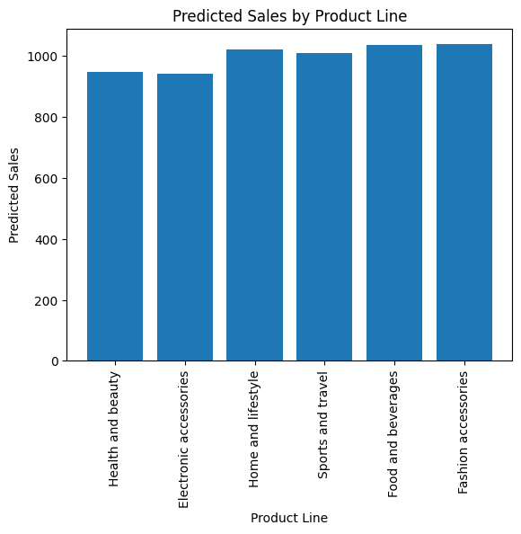

```python
# plot a bar chart of predicted sales by product line
plt.bar(df['Product line'], predicted_df['predicted_total_sales'])
plt.xticks(rotation=90)
plt.xlabel('Product Line')
plt.ylabel('Predicted Sales')
plt.title('Predicted Sales by Product Line');
```

### Conclusion

Based on the analysis of the supermarket dataset, the following recommendations can be made:

Targeting specific cities and customer types can increase the number of transactions. Improving the supermarket rating by gender can also lead to increased customer satisfaction and loyalty.

Implementing strategies to minimize the amount of tax paid can improve overall profitability.

However, the Random Forest classification algorithm performed relatively poorly in predicting customer ratings. It is recommended to explore alternative algorithms or incorporate additional relevant data to improve prediction accuracy and gain insights into customer preferences for enhancing customer satisfaction and loyalty.

Overall, these recommendations can help the supermarket make data-driven decisions and allocate resources effectively, leading to improved profitability and customer satisfaction.